# Rohith_Kumar_Thakur_26-12-2022

### Part 0 Reading the data

#### import the required libraries

```python
import pandas as pd
```

#### reading/loading the file into pandas dataframe

```python
df = pd.read_excel('C:/Users/ROHITH KUMAR/Downloads/Fytlyff_DS_Interview.xlsx')
```

#### viewing the top 5 rows of the data

```python
df.head()
```

|  | Year | Month | Laptop/Desktop | Type_of_Customers? | Coming from | Place_in_India | Level 1 | Level 2 | Level 3 | Level 4 |
| --- | --- | --- | --- | --- | --- | --- | --- | --- | --- | --- |
| 0 | 2020 | Jan | Desktop_Website | Existing_Customer | Came_From_LinkedIn | Bengaluru | NaN | NaN | 56892 | 17178 |
| 1 | 2020 | Jan | Desktop_Website | Existing_Customer | Came_From_LinkedIn | Hyderabad | NaN | NaN | 41460 | 11916 |
| 2 | 2020 | Jan | Desktop_Website | Existing_Customer | Came_From_LinkedIn | Dehradun | NaN | NaN | 55561 | 19461 |
| 3 | 2020 | Jan | Desktop_Website | Existing_Customer | Came_From_LinkedIn | Indore | NaN | NaN | 320923 | 110667 |
| 4 | 2020 | Jan | Desktop_Website | Existing_Customer | Came_From_LinkedIn | Pune | NaN | NaN | 220937 | 46033 |

```python
df.shape
```

```
(2160, 10)
```

#### Print all the column names

```python
df.columns
```

```
Index(['Year', 'Month', 'Laptop/Desktop', 'Type_of_Customers?', 'Coming from',
       'Place_in_India', 'Level 1', 'Level 2', 'Level 3', 'Level 4'],
      dtype='object')
```

#### print the data types in each column

```python
df.info()
```

```
<class 'pandas.core.frame.DataFrame'>
RangeIndex: 2160 entries, 0 to 2159
Data columns (total 10 columns):
 #   Column              Non-Null Count  Dtype
---  ------              --------------  -----
 0   Year                2160 non-null   int64
 1   Month               2160 non-null   object
 2   Laptop/Desktop      2160 non-null   object
 3   Type_of_Customers?  2160 non-null   object
 4   Coming from         2160 non-null   object
 5   Place_in_India      2160 non-null   object
 6   Level 1             1081 non-null   float64
 7   Level 2             1081 non-null   float64
 8   Level 3             2160 non-null   int64
 9   Level 4             2160 non-null   int64
dtypes: float64(2), int64(3), object(5)
memory usage: 168.9+ KB
```

#### Print the cities of India from which the page was accessed

```python
df['Place_in_India'].value_counts()
```

```
Bengaluru    432
Hyderabad    432
Dehradun     432
Indore       432
Pune         432
Name: Place_in_India, dtype: int64
```

#### Print the cities of India from which the page was accessed

```python
cities = df['Place_in_India'].unique()
print(cities)
```

```
['Bengaluru' 'Hyderabad' 'Dehradun' 'Indore' 'Pune']
```

#### Which columns are having some values missing in them?

```python
df.isnull().sum()
```

```
Year                     0
Month                    0
Laptop/Desktop           0
Type_of_Customers?       0
Coming from              0
Place_in_India           0
Level 1               1079
Level 2               1079
Level 3                  0
Level 4                  0
dtype: int64
```

#### Which columns are having some values missing in them?

```python
pd.DataFrame(df.isna().sum(), columns = ['count of Nan'])
```

|  | count of Nan |
| --- | --- |
| Year | 0 |
| Month | 0 |
| Laptop/Desktop | 0 |
| Type_of_Customers? | 0 |
| Coming from | 0 |
| Place_in_India | 0 |
| Level 1 | 1079 |
| Level 2 | 1079 |
| Level 3 | 0 |
| Level 4 | 0 |

### The columns that have NaN values are

1. How_many_Landed_on_our_Page
2. How_many_Landed_on_the_our_Page_and_clicked_on_a_button

#### Give the number of new customers who are from Pune and came from LinkedIn

```python
# df1 = df.loc[(df['Type_of_Customers?'] == 'New_Customer') & (df['Place_in_India'] == 'Pune') &
#        (df['Coming from'] == 'Came_From_LinkedIn')]
# df1.head()

# the number of new customers who are from pune and came from linkedin is

count = df['Type_of_Customers?'].value_counts()
print('number of new customers who are from pune and came from linkedin is :',  count)
```

```
number of new customers who are from pune and came from linkedin is : Existing_Customer    1080
New_Customer         1080
Name: Type_of_Customers?, dtype: int64
```

```python
df.loc[(df['Type_of_Customers?'] == 'New_Customer') & (df['Place_in_India'] == 'Pune') &
       (df['Coming from'] == 'Came_From_LinkedIn')]['Type_of_Customers?'].value_counts()
```

```
New_Customer    72
Name: Type_of_Customers?, dtype: int64
```

```python
df.head()
```

|  | Year | Month | Laptop/Desktop | Type_of_Customers? | Coming from | Place_in_India | Level 1 | Level 2 | Level 3 | Level 4 |
| --- | --- | --- | --- | --- | --- | --- | --- | --- | --- | --- |
| 0 | 2020 | Jan | Desktop_Website | Existing_Customer | Came_From_LinkedIn | Bengaluru | NaN | NaN | 56892 | 17178 |
| 1 | 2020 | Jan | Desktop_Website | Existing_Customer | Came_From_LinkedIn | Hyderabad | NaN | NaN | 41460 | 11916 |
| 2 | 2020 | Jan | Desktop_Website | Existing_Customer | Came_From_LinkedIn | Dehradun | NaN | NaN | 55561 | 19461 |
| 3 | 2020 | Jan | Desktop_Website | Existing_Customer | Came_From_LinkedIn | Indore | NaN | NaN | 320923 | 110667 |
| 4 | 2020 | Jan | Desktop_Website | Existing_Customer | Came_From_LinkedIn | Pune | NaN | NaN | 220937 | 46033 |

```python
def data_cleaning(row):
    # 2. replace null values with average values in the level 1 and level 2 columns

    df['Level 1'].fillna(value = round(df['Level 1'].mean(),2), inplace = True)
    df['Level 2'].fillna(value = round(df['Level 2'].mean(),2), inplace = True)

    # 3.In column ‘B’ replace Jan with january, feb with february, march with march,

    df.replace({'Month': {'Jan': 'January','Feb': 'February', 'Mar': 'March', 'Apr': 'April','Jun': 'June',
    'Jul': 'July','Aug': 'August', 'Sep': 'September','Oct': 'October','Nov': 'November', 'Dec': 'December'}}, inplace = True)

    # 4.In column ‘E’ Replace “Came_From_LinkedIn” with “From LinkedIn” and “Landed_Directly” with “Direct_traffic”

    df['Coming from'] = df['Coming from'].apply(lambda x: x.replace('Landed_Directly', 'Direct_traffic'))
    df['Coming from'] = df['Coming from'].apply(lambda x: x.replace('Came_From_LinkedIn', 'From LinkedIn'))

    # 1. 1.Create a column at the end, named “inc/dec percentage”, (“Level 1” – “Level 4”) / “Level 1” * 100
    # which would give the growth/reduction percentage in numbers of level 1 vs level 4 columns

    df['inc/dec percentage'] = round(((df['Level 1'] - df['Level 4'])/(df['Level 1']))*100, 2)
```

```python
#dic = {'Jan': 'January','Feb': 'February', 'Mar': 'March', 'Apr': 'April',
# 'Jun': 'June','Jul': 'July','Aug': 'August','Sep': 'September','Oct': 'October','Nov': 'November','Dec': 'December'}
```

```python
df.apply(data_cleaning)
df
```

|  | Year | Month | Laptop/Desktop | Type_of_Customers? | Coming from | Place_in_India | Level 1 | Level 2 | Level 3 | Level 4 | inc/dec percentage |
| --- | --- | --- | --- | --- | --- | --- | --- | --- | --- | --- | --- |
| 0 | 2020 | January | Desktop_Website | Existing_Customer | From LinkedIn | Bengaluru | 783870.22 | 358215.42 | 56892 | 17178 | 97.81 |
| 1 | 2020 | January | Desktop_Website | Existing_Customer | From LinkedIn | Hyderabad | 783870.22 | 358215.42 | 41460 | 11916 | 98.48 |
| 2 | 2020 | January | Desktop_Website | Existing_Customer | From LinkedIn | Dehradun | 783870.22 | 358215.42 | 55561 | 19461 | 97.52 |
| 3 | 2020 | January | Desktop_Website | Existing_Customer | From LinkedIn | Indore | 783870.22 | 358215.42 | 320923 | 110667 | 85.88 |
| 4 | 2020 | January | Desktop_Website | Existing_Customer | From LinkedIn | Pune | 783870.22 | 358215.42 | 220937 | 46033 | 94.13 |
| ... | ... | ... | ... | ... | ... | ... | ... | ... | ... | ... | ... |
| 2155 | 2022 | December | Laptop_Website | New_Customer | Unidentified_Sources | Bengaluru | 67299.00 | 21255.00 | 6984 | 1882 | 97.20 |
| 2156 | 2022 | December | Laptop_Website | New_Customer | Unidentified_Sources | Hyderabad | 430294.00 | 156510.00 | 46676 | 16703 | 96.12 |
| 2157 | 2022 | December | Laptop_Website | New_Customer | Unidentified_Sources | Dehradun | 48713.00 | 27770.00 | 7515 | 2089 | 95.71 |
| 2158 | 2022 | December | Laptop_Website | New_Customer | Unidentified_Sources | Indore | 593021.00 | 310836.00 | 161575 | 78465 | 86.77 |
| 2159 | 2022 | December | Laptop_Website | New_Customer | Unidentified_Sources | Pune | 372897.00 | 123057.00 | 48802 | 19441 | 94.79 |

2160 rows × 11 columns

```python
df
```

|  | Year | Month | Laptop/Desktop | Type_of_Customers? | Coming from | Place_in_India | Level 1 | Level 2 | Level 3 | Level 4 | inc/dec percentage |
| --- | --- | --- | --- | --- | --- | --- | --- | --- | --- | --- | --- |
| 0 | 2020 | January | Desktop_Website | Existing_Customer | From LinkedIn | Bengaluru | 783870.22 | 358215.42 | 56892 | 17178 | 97.81 |
| 1 | 2020 | January | Desktop_Website | Existing_Customer | From LinkedIn | Hyderabad | 783870.22 | 358215.42 | 41460 | 11916 | 98.48 |
| 2 | 2020 | January | Desktop_Website | Existing_Customer | From LinkedIn | Dehradun | 783870.22 | 358215.42 | 55561 | 19461 | 97.52 |
| 3 | 2020 | January | Desktop_Website | Existing_Customer | From LinkedIn | Indore | 783870.22 | 358215.42 | 320923 | 110667 | 85.88 |
| 4 | 2020 | January | Desktop_Website | Existing_Customer | From LinkedIn | Pune | 783870.22 | 358215.42 | 220937 | 46033 | 94.13 |
| ... | ... | ... | ... | ... | ... | ... | ... | ... | ... | ... | ... |
| 2155 | 2022 | December | Laptop_Website | New_Customer | Unidentified_Sources | Bengaluru | 67299.00 | 21255.00 | 6984 | 1882 | 97.20 |
| 2156 | 2022 | December | Laptop_Website | New_Customer | Unidentified_Sources | Hyderabad | 430294.00 | 156510.00 | 46676 | 16703 | 96.12 |
| 2157 | 2022 | December | Laptop_Website | New_Customer | Unidentified_Sources | Dehradun | 48713.00 | 27770.00 | 7515 | 2089 | 95.71 |
| 2158 | 2022 | December | Laptop_Website | New_Customer | Unidentified_Sources | Indore | 593021.00 | 310836.00 | 161575 | 78465 | 86.77 |
| 2159 | 2022 | December | Laptop_Website | New_Customer | Unidentified_Sources | Pune | 372897.00 | 123057.00 | 48802 | 19441 | 94.79 |

2160 rows × 11 columns

### Part 2: Descriptive statistics

```python
def descriptive_stats(Year, Month, Laptop_Desktop, Type_of_Customers, Coming_from):

    # Minimum of Level1, Level2, Level3, Level4
    min_val = df[['Level 1','Level 2','Level 3','Level 4']].min()

    # Give the maximum value of “Level 2” / “Level 1” among those who came directly to the via desktop website
    df['Level2/Level1'] = df['Level 2']/df['Level 1']
    max_ratio = df.loc[(df['Laptop/Desktop'] == 'Desktop_Website')]
    max_value = max_ratio['Level2/Level1'].max()

    # let the new dataframe be newdf
    newdf = df.loc[(df['Year'] == Year) & (df['Month'] == Month) & (df['Laptop/Desktop'] == Laptop_Desktop) & (df['Type_of_Customers?'] == Type_of_Customers) & (df['Coming from'] ==Coming_from)]

    # Generates the summary statistics
    des_stat = newdf.describe()

    return (print('The new Dataframe \n'),
            display(newdf),
            print('The descriptive stats of the new dataframe \n'),
            display(des_stat),
            print('minimum value in the columns\n',min_val, '\n'),
            print('the max value of ratio level2/level1 for Desktop_Website is: ', max_value, '\n'),
            print('The Unique value in Month column is\n', newdf['Month'].unique(),'\n','The data type is\n', newdf['Month'].dtype, '\n'),
           print('The Unique value in Laptop/Desktop column is\n', newdf['Laptop/Desktop'].unique(),'\n','The data type is\n', newdf['Laptop/Desktop'].dtype, '\n'),
           print('The Unique value in Type_of_Customers? column is\n', newdf['Type_of_Customers?'].unique(),'\n','The data type is\n', newdf['Type_of_Customers?'].dtype, '\n'),
            print('The Unique value in Coming from column is\n', newdf['Coming from'].unique(),'\n','The data type is\n', newdf['Coming from'].dtype, '\n'),
           )
```

```python
des_stat = descriptive_stats(Year = 2020, Month = 'January', Laptop_Desktop ='Desktop_Website' , Type_of_Customers = 'Existing_Customer', Coming_from = 'From LinkedIn')
```

```
The new Dataframe
```

|  | Year | Month | Laptop/Desktop | Type_of_Customers? | Coming from | Place_in_India | Level 1 | Level 2 | Level 3 | Level 4 | inc/dec percentage | Level2/Level1 |
| --- | --- | --- | --- | --- | --- | --- | --- | --- | --- | --- | --- | --- |
| 0 | 2020 | January | Desktop_Website | Existing_Customer | From LinkedIn | Bengaluru | 783870.22 | 358215.42 | 56892 | 17178 | 97.81 | 0.456983 |
| 1 | 2020 | January | Desktop_Website | Existing_Customer | From LinkedIn | Hyderabad | 783870.22 | 358215.42 | 41460 | 11916 | 98.48 | 0.456983 |
| 2 | 2020 | January | Desktop_Website | Existing_Customer | From LinkedIn | Dehradun | 783870.22 | 358215.42 | 55561 | 19461 | 97.52 | 0.456983 |
| 3 | 2020 | January | Desktop_Website | Existing_Customer | From LinkedIn | Indore | 783870.22 | 358215.42 | 320923 | 110667 | 85.88 | 0.456983 |
| 4 | 2020 | January | Desktop_Website | Existing_Customer | From LinkedIn | Pune | 783870.22 | 358215.42 | 220937 | 46033 | 94.13 | 0.456983 |

```
The descriptive stats of the new dataframe
```

|  | Year | Level 1 | Level 2 | Level 3 | Level 4 | inc/dec percentage | Level2/Level1 |
| --- | --- | --- | --- | --- | --- | --- | --- |
| count | 5.0 | 5.00 | 5.00 | 5.00000 | 5.000000 | 5.000000 | 5.000000 |
| mean | 2020.0 | 783870.22 | 358215.42 | 139154.60000 | 41051.000000 | 94.764000 | 0.456983 |
| std | 0.0 | 0.00 | 0.00 | 125526.26456 | 41097.762208 | 5.244276 | 0.000000 |
| min | 2020.0 | 783870.22 | 358215.42 | 41460.00000 | 11916.000000 | 85.880000 | 0.456983 |
| 25% | 2020.0 | 783870.22 | 358215.42 | 55561.00000 | 17178.000000 | 94.130000 | 0.456983 |
| 50% | 2020.0 | 783870.22 | 358215.42 | 56892.00000 | 19461.000000 | 97.520000 | 0.456983 |
| 75% | 2020.0 | 783870.22 | 358215.42 | 220937.00000 | 46033.000000 | 97.810000 | 0.456983 |
| max | 2020.0 | 783870.22 | 358215.42 | 320923.00000 | 110667.000000 | 98.480000 | 0.456983 |

```
minimum value in the columns
 Level 1    24567.0
Level 2     8425.0
Level 3     3761.0
Level 4      766.0
dtype: float64

the max value of ratio level2/level1 for Desktop_Website is:  0.8980720288554845

The Unique value in Month column is
 ['January']
 The data type is
 object

The Unique value in Laptop/Desktop column is
 ['Desktop_Website']
 The data type is
 object

The Unique value in Type_of_Customers? column is
 ['Existing_Customer']
 The data type is
 object

The Unique value in Coming from column is
 ['From LinkedIn']
 The data type is
 object
```

### Part 3: Prescriptive statistics

#### 1.What are the top 3 “Place_in_India” on the basis of column “Level 4” for the year 2020 and 2022 separately ?

```python
# creating the sum of level 4 column
df['sum_of_level4'] = df['Level 4'].sum()

# Adding rank according to level 4 columnd
df['rank'] = df.groupby('Year')['Level 4'].rank(ascending=False)
df = df.sort_values(by = 'rank')

df1 = df.copy()

# filtering years = 2020 and 2022
df2 = df1.loc[(df['Year'] == 2020) | (df['Year'] == 2022) ]
df2

# taking first 3 records from group by object
df3 = df2.groupby(by = ['Year'])[['Year', 'rank', 'Place_in_India', 'sum_of_level4' ]]
df3.head(3).sort_values(by = ['Year', 'rank'])
```

|  | Year | rank | Place_in_India | sum_of_level4 |
| --- | --- | --- | --- | --- |
| 263 | 2020 | 1.0 | Indore | 127917989 |
| 262 | 2020 | 2.0 | Dehradun | 127917989 |
| 323 | 2020 | 3.0 | Indore | 127917989 |
| 1764 | 2022 | 1.0 | Pune | 127917989 |
| 1914 | 2022 | 2.0 | Pune | 127917989 |
| 1760 | 2022 | 3.0 | Bengaluru | 127917989 |

#### Please, provide the data for all the cities & for all the years,

```python
# creating new columns sum of level4/sum of level1, sum of level2/sum of level1, sum of level3/sum of level1
df['sum_level4/sum_level1'] = (df['Level 4'].sum()) / (df['Level 1'].sum())
df['sum_level3/sum_level1'] = (df['Level 3'].sum()) / (df['Level 1'].sum())
df['sum_level2/sum_level1'] = (df['Level 2'].sum()) / (df['Level 1'].sum())
df4 = df[['Place_in_India', 'Year','sum_level4/sum_level1','sum_level3/sum_level1','sum_level2/sum_level1']].sort_values(by = ['Year'], ascending = True)
df4
```

|  | Place_in_India | Year | sum_level4/sum_level1 | sum_level3/sum_level1 | sum_level2/sum_level1 |
| --- | --- | --- | --- | --- | --- |
| 13 | Indore | 2020 | 0.07555 | 0.192726 | 0.456983 |
| 333 | Indore | 2020 | 0.07555 | 0.192726 | 0.456983 |
| 89 | Pune | 2020 | 0.07555 | 0.192726 | 0.456983 |
| 448 | Indore | 2020 | 0.07555 | 0.192726 | 0.456983 |
| 70 | Bengaluru | 2020 | 0.07555 | 0.192726 | 0.456983 |
| ... | ... | ... | ... | ... | ... |
| 1444 | Pune | 2022 | 0.07555 | 0.192726 | 0.456983 |
| 1852 | Dehradun | 2022 | 0.07555 | 0.192726 | 0.456983 |
| 1697 | Dehradun | 2022 | 0.07555 | 0.192726 | 0.456983 |
| 1732 | Dehradun | 2022 | 0.07555 | 0.192726 | 0.456983 |
| 1482 | Dehradun | 2022 | 0.07555 | 0.192726 | 0.456983 |

2160 rows × 5 columns

#### What are the bottom 3 “Place_in_India” on the basis of column “Level 4”/“Level 1” for the year 2021 and 2022 separately?

```python
df['level4/level1'] = df['Level 4']/df['Level 1']
df11 = df.loc[df['Year'] == 2021].groupby(by = 'Place_in_India')[['Year','level4/level1']].mean().sort_values(by = 'level4/level1', ascending = False)
df11.tail(3)
```

| Place_in_India | Year | level4/level1 |
| --- | --- | --- |
| Pune | 2021.0 | 0.090195 |
| Bengaluru | 2021.0 | 0.079632 |
| Dehradun | 2021.0 | 0.063874 |

```python
df12 = df.loc[df['Year'] == 2022].groupby(by = 'Place_in_India')[['Year','level4/level1']].mean().sort_values(by = 'level4/level1', ascending = False)
df12.tail(3)
```

| Place_in_India | Year | level4/level1 |
| --- | --- | --- |
| Bengaluru | 2022.0 | 0.071927 |
| Pune | 2022.0 | 0.069453 |
| Dehradun | 2022.0 | 0.057128 |

#### Which place in India is having “Level 4” value greater than 150000 most of the times?

```python
df.loc[(df['Level 4'] > 150000)].Place_in_India.unique()
```

```
array(['Pune', 'Indore', 'Dehradun', 'Bengaluru', 'Hyderabad'],
      dtype=object)
```

#### Which place in India is having least number of existing customers?

```python
df.loc[(df['Type_of_Customers?'] == 'Existing_Customer')].groupby(by ='Place_in_India', sort=True).count()

# There are equal number of customers in all city where type_of_customers == Existing_customer
```

| Place_in_India | Year | Month | Laptop/Desktop | Type_of_Customers? | Coming from | Level 1 | Level 2 | Level 3 | Level 4 | inc/dec percentage | Level2/Level1 | sum_of_level4 | rank | sum_level4/sum_level1 | sum_level3/sum_level1 | sum_level2/sum_level1 | level4/level1 |
| --- | --- | --- | --- | --- | --- | --- | --- | --- | --- | --- | --- | --- | --- | --- | --- | --- | --- |
| Bengaluru | 216 | 216 | 216 | 216 | 216 | 216 | 216 | 216 | 216 | 216 | 216 | 216 | 216 | 216 | 216 | 216 | 216 |
| Dehradun | 216 | 216 | 216 | 216 | 216 | 216 | 216 | 216 | 216 | 216 | 216 | 216 | 216 | 216 | 216 | 216 | 216 |
| Hyderabad | 216 | 216 | 216 | 216 | 216 | 216 | 216 | 216 | 216 | 216 | 216 | 216 | 216 | 216 | 216 | 216 | 216 |
| Indore | 216 | 216 | 216 | 216 | 216 | 216 | 216 | 216 | 216 | 216 | 216 | 216 | 216 | 216 | 216 | 216 | 216 |
| Pune | 216 | 216 | 216 | 216 | 216 | 216 | 216 | 216 | 216 | 216 | 216 | 216 | 216 | 216 | 216 | 216 | 216 |

### Part 4 Simple Machine learning questions

```python
df7
```

[output not shown]

2160 rows × 20 columns

```python
df7.replace({'month1': {1: '01',2: '02', 3: '03', 4: '04',5: '05', 6: '06',
    7: '07',8: '08', 9: '09',10: '10',11: '11', 12: '12'}}, inplace = True)
```

```python
df7['yearmonth1'] = df7['Year'].astype('string').str.cat(df7['month1'], sep ="-")
```

```python
# Convert yearmonth1 into Datetime
df7['yearmonth1']=pd.to_datetime(df7['yearmonth1'])
```

```python
# making yearmonth1 column as index
# df7.set_index('yearmonth1',inplace=True)
```

```python
# reset index
# df7.reset_index(inplace = True)
```

```python
df7
```

|  | Year | Month | Laptop/Desktop | Type_of_Customers? | Coming from | Place_in_India | Level 1 | Level 2 | Level 3 | Level 4 | ... | Level2/Level1 | sum_of_level4 | rank | sum_level4/sum_level1 | sum_level3/sum_level1 | sum_level2/sum_level1 | level4/level1 | yearmonth | month1 | yearmonth1 |
| --- | --- | --- | --- | --- | --- | --- | --- | --- | --- | --- | --- | --- | --- | --- | --- | --- | --- | --- | --- | --- | --- |
| 1764 | 2022 | June | Desktop_Website | New_Customer | Direct_traffic | Pune | 9083552.00 | 4079301.00 | 1942557 | 923720 | ... | 0.449087 | 127917989 | 1.0 | 0.07555 | 0.192726 | 0.456983 | 0.101691 | 2022_June | 06 | 2022-06-01 |
| 263 | 2020 | May | Desktop_Website | New_Customer | Direct_traffic | Indore | 2739053.00 | 2141881.00 | 1649732 | 1251258 | ... | 0.781979 | 127917989 | 1.0 | 0.07555 | 0.192726 | 0.456983 | 0.456821 | 2020_May | 05 | 2020-05-01 |
| 1284 | 2021 | October | Desktop_Website | New_Customer | Direct_traffic | Pune | 8188402.00 | 3435272.00 | 862600 | 558073 | ... | 0.419529 | 127917989 | 1.0 | 0.07555 | 0.192726 | 0.456983 | 0.068154 | 2021_October | 10 | 2021-10-01 |
| 983 | 2021 | May | Desktop_Website | New_Customer | Direct_traffic | Indore | 2341270.00 | 892572.00 | 557801 | 447909 | ... | 0.381234 | 127917989 | 2.0 | 0.07555 | 0.192726 | 0.456983 | 0.191310 | 2021_May | 05 | 2021-05-01 |
| 262 | 2020 | May | Desktop_Website | New_Customer | Direct_traffic | Dehradun | 1412563.00 | 1121317.00 | 994925 | 873534 | ... | 0.793817 | 127917989 | 2.0 | 0.07555 | 0.192726 | 0.456983 | 0.618404 | 2020_May | 05 | 2020-05-01 |
| ... | ... | ... | ... | ... | ... | ... | ... | ... | ... | ... | ... | ... | ... | ... | ... | ... | ... | ... | ... | ... | ... |
| 1480 | 2022 | January | Laptop_Website | Existing_Customer | Unidentified_Sources | Bengaluru | 783870.22 | 358215.42 | 6711 | 1040 | ... | 0.456983 | 127917989 | 719.0 | 0.07555 | 0.192726 | 0.456983 | 0.001327 | 2022_January | 01 | 2022-01-01 |
| 1420 | 2021 | December | Laptop_Website | Existing_Customer | Unidentified_Sources | Bengaluru | 783870.22 | 358215.42 | 7222 | 1102 | ... | 0.456983 | 127917989 | 719.0 | 0.07555 | 0.192726 | 0.456983 | 0.001406 | 2021_December | 12 | 2021-12-01 |
| 101 | 2020 | February | Laptop_Website | Existing_Customer | Unidentified_Sources | Hyderabad | 783870.22 | 358215.42 | 7964 | 1697 | ... | 0.456983 | 127917989 | 720.0 | 0.07555 | 0.192726 | 0.456983 | 0.002165 | 2020_February | 02 | 2020-02-01 |
| 1422 | 2021 | December | Laptop_Website | Existing_Customer | Unidentified_Sources | Dehradun | 783870.22 | 358215.42 | 10240 | 860 | ... | 0.456983 | 127917989 | 720.0 | 0.07555 | 0.192726 | 0.456983 | 0.001097 | 2021_December | 12 | 2021-12-01 |
| 1482 | 2022 | January | Laptop_Website | Existing_Customer | Unidentified_Sources | Dehradun | 783870.22 | 358215.42 | 8901 | 766 | ... | 0.456983 | 127917989 | 720.0 | 0.07555 | 0.192726 | 0.456983 | 0.000977 | 2022_January | 01 | 2022-01-01 |

2160 rows × 21 columns

```python
df7 = df7.sort_values(by = 'yearmonth1', ascending = True)
```

```python
df7.reset_index(inplace = True)
```

```python
df7.drop('index', axis = 1, inplace = True)
```

```python
df7
```

|  | Year | Month | Laptop/Desktop | Type_of_Customers? | Coming from | Place_in_India | Level 1 | Level 2 | Level 3 | Level 4 | ... | Level2/Level1 | sum_of_level4 | rank | sum_level4/sum_level1 | sum_level3/sum_level1 | sum_level2/sum_level1 | level4/level1 | yearmonth | month1 | yearmonth1 |
| --- | --- | --- | --- | --- | --- | --- | --- | --- | --- | --- | --- | --- | --- | --- | --- | --- | --- | --- | --- | --- | --- |
| 0 | 2020 | January | Desktop_Website | Existing_Customer | Direct_traffic | Dehradun | 783870.22 | 358215.42 | 91479 | 24363 | ... | 0.456983 | 127917989 | 406.0 | 0.07555 | 0.192726 | 0.456983 | 0.031080 | 2020_January | 01 | 2020-01-01 |
| 1 | 2020 | January | Desktop_Website | New_Customer | Unidentified_Sources | Dehradun | 101453.00 | 79201.00 | 17203 | 10064 | ... | 0.780667 | 127917989 | 588.0 | 0.07555 | 0.192726 | 0.456983 | 0.099199 | 2020_January | 01 | 2020-01-01 |
| 2 | 2020 | January | Desktop_Website | Existing_Customer | Unidentified_Sources | Bengaluru | 783870.22 | 358215.42 | 32119 | 6900 | ... | 0.456983 | 127917989 | 630.0 | 0.07555 | 0.192726 | 0.456983 | 0.008802 | 2020_January | 01 | 2020-01-01 |
| 3 | 2020 | January | Laptop_Website | New_Customer | Direct_traffic | Indore | 2160270.00 | 1209633.00 | 529460 | 249974 | ... | 0.559945 | 127917989 | 34.0 | 0.07555 | 0.192726 | 0.456983 | 0.115714 | 2020_January | 01 | 2020-01-01 |
| 4 | 2020 | January | Desktop_Website | Existing_Customer | From LinkedIn | Bengaluru | 783870.22 | 358215.42 | 56892 | 17178 | ... | 0.456983 | 127917989 | 493.0 | 0.07555 | 0.192726 | 0.456983 | 0.021914 | 2020_January | 01 | 2020-01-01 |
| ... | ... | ... | ... | ... | ... | ... | ... | ... | ... | ... | ... | ... | ... | ... | ... | ... | ... | ... | ... | ... | ... |
| 2155 | 2022 | December | Desktop_Website | New_Customer | Direct_traffic | Pune | 6923521.00 | 2976129.00 | 1764309 | 134854 | ... | 0.429858 | 127917989 | 82.0 | 0.07555 | 0.192726 | 0.456983 | 0.019478 | 2022_December | 12 | 2022-12-01 |
| 2156 | 2022 | December | Desktop_Website | New_Customer | From LinkedIn | Bengaluru | 71842.00 | 39408.00 | 22067 | 16123 | ... | 0.548537 | 127917989 | 456.0 | 0.07555 | 0.192726 | 0.456983 | 0.224423 | 2022_December | 12 | 2022-12-01 |
| 2157 | 2022 | December | Desktop_Website | Existing_Customer | Unidentified_Sources | Dehradun | 783870.22 | 358215.42 | 24604 | 3476 | ... | 0.456983 | 127917989 | 625.0 | 0.07555 | 0.192726 | 0.456983 | 0.004434 | 2022_December | 12 | 2022-12-01 |
| 2158 | 2022 | December | Desktop_Website | Existing_Customer | Unidentified_Sources | Pune | 783870.22 | 358215.42 | 33798 | 7358 | ... | 0.456983 | 127917989 | 570.0 | 0.07555 | 0.192726 | 0.456983 | 0.009387 | 2022_December | 12 | 2022-12-01 |
| 2159 | 2022 | December | Desktop_Website | Existing_Customer | Direct_traffic | Bengaluru | 783870.22 | 358215.42 | 81644 | 21060 | ... | 0.456983 | 127917989 | 380.0 | 0.07555 | 0.192726 | 0.456983 | 0.026867 | 2022_December | 12 | 2022-12-01 |

2160 rows × 21 columns

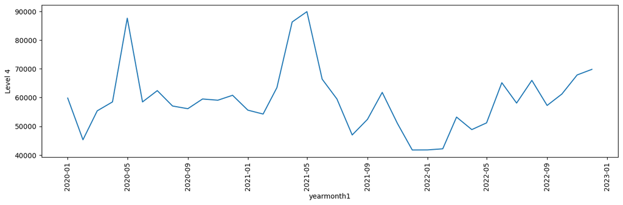

```python
# Plot of level 4 with yearmonth1 to see the trend across the years
plt.figure(figsize = (15,4))
sns.lineplot(data = df7, x = 'yearmonth1', y = 'Level 4', ci = None)
plt.xticks(rotation = 90)
plt.show()
```